# Correspondence analysis: practice with R

2025-04-14

### Данные

В частотной базе данных Поэтического корпуса НКРЯ были размечены части речи у слов, которые попадают в зону рифмовки.

```r
library(tidyverse)
rhymes.table <- data.frame(s1820s = c(535, 152, 37, 248, 10),
                           s1860s = c(2034, 582, 183, 965, 52),
                       s1920s = c(1913, 378, 145, 577, 57),
                       s1960s = c(1071, 223, 105, 361, 38))
row.names(rhymes.table) = c("NOUN", "ADJ", "ADV", "VERB", "GRAM")
# Gram -- CCONJ, SCONJ or PART
rhymes.table
```

```
##      s1820s s1860s s1920s s1960s
## NOUN    535   2034   1913   1071
## ADJ     152    582    378    223
## ADV      37    183    145    105
## VERB    248    965    577    361
## GRAM     10     52     57     38
```

Пользуясь таблицей сопряженности, визуализируйте связь между декадами и частями речи. Какая кумулятивная объясненная дисперсия у визуализации по Dim1 и Dim2? Проанализируйте визуализацию и сформулируйте ваши выводы, касающиеся ассоциации между временем и употреблением частей речи в зоне рифмовке (макс. 5 интересных как положительных, так и нейтральных и отрицательных ассоциаций).

### Chisq test

```r
rhymes.chisq <- chisq.test(rhymes.table)
rhymes.chisq$exp
```

```
##         s1820s     s1860s     s1920s     s1960s
## NOUN 564.14711 2192.24581 1763.67784 1032.92924
## ADJ  135.62694  527.03911  424.00683  248.32713
## ADV   47.74881  185.54935  149.27581   87.42603
## VERB 218.52700  849.18436  683.17505  400.11359
## GRAM  15.95013   61.98138   49.86447   29.20401
```

```r
rhymes.chisq
```

```
##
##  Pearson's Chi-squared test
##
## data:  rhymes.table
## X-squared = 95.96, df = 12, p-value = 3.431e-15
```

### Effect size

```r
library(confintr)
cramersv(rhymes.chisq)
```

```
## [1] 0.05752557
```

### Baloon plot

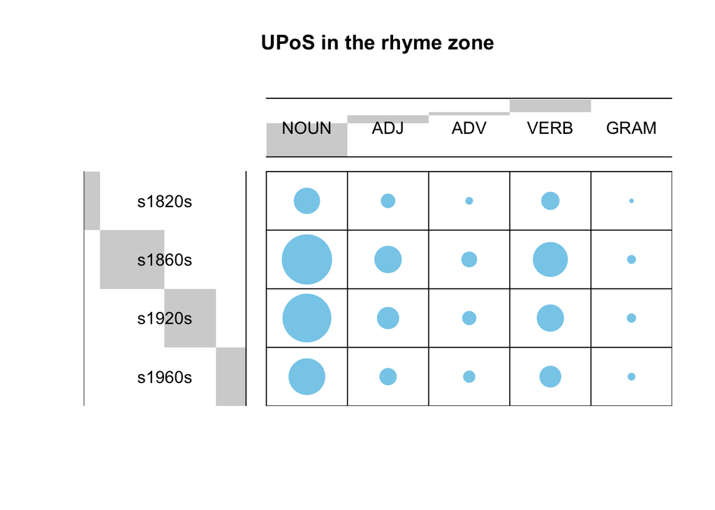

```r
library("gplots")
rhymes.table |> as.matrix() |> as.table() |>
  balloonplot(main ="UPoS in the rhyme zone", xlab ="", ylab="",
              label = FALSE, show.margins = FALSE)
```

# Mosaic plot

```r
library(vcd)
```

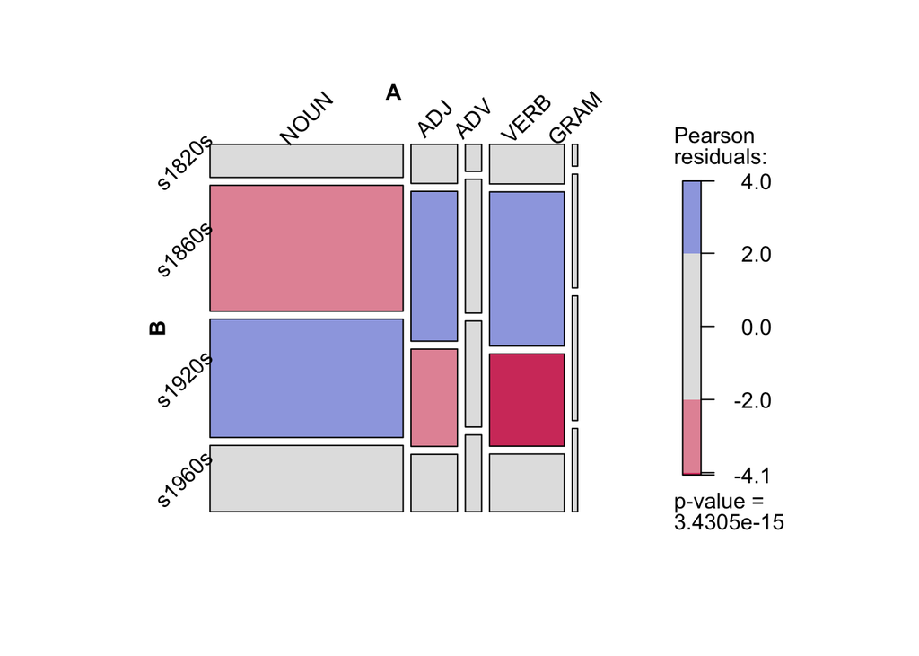

```r
rhymes.table |> as.matrix() |> as.table() |>
  mosaic(shade = TRUE, split_vertical = TRUE, rot_labels=c(45,90,0,45))
```

```r
library(factoextra)
```

```r
library(FactoMineR)
ca.model <- CA(rhymes.table, ncp = 3, graph = FALSE)
print(ca.model)
```

```
## **Results of the Correspondence Analysis (CA)**
## The row variable has  5  categories; the column variable has 4 categories
## The chi square of independence between the two variables is equal to 95.95994 (p-value =  3.43051e-15 ).
## *The results are available in the following objects:
##
##    name              description
## 1  "$eig"            "eigenvalues"
## 2  "$col"            "results for the columns"
## 3  "$col$coord"      "coord. for the columns"
## 4  "$col$cos2"       "cos2 for the columns"
## 5  "$col$contrib"    "contributions of the columns"
## 6  "$row"            "results for the rows"
## 7  "$row$coord"      "coord. for the rows"
## 8  "$row$cos2"       "cos2 for the rows"
## 9  "$row$contrib"    "contributions of the rows"
## 10 "$call"           "summary called parameters"
## 11 "$call$marge.col" "weights of the columns"
## 12 "$call$marge.row" "weights of the rows"
```

```r
ca.model$eig
```

```
##         eigenvalue percentage of variance cumulative percentage of variance
## dim 1 9.170860e-03            92.37764923                          92.37765
## dim 2 7.552038e-04             7.60713268                          99.98478
## dim 3 1.510788e-06             0.01521809                         100.00000
```

```r
summary(ca.model)
```

```
##
## Call:
## CA(X = rhymes.table, ncp = 3, graph = FALSE)
##
## The chi square of independence between the two variables is equal to 95.95994 (p-value =  3.43051e-15 ).
##
## Eigenvalues
##                        Dim.1   Dim.2   Dim.3
## Variance               0.009   0.001   0.000
## % of var.             92.378   7.607   0.015
## Cumulative % of var.  92.378  99.985 100.000
##
## Rows
##          Iner*1000    Dim.1    ctr   cos2    Dim.2    ctr   cos2    Dim.3
## NOUN   |     2.791 |  0.069 29.545  0.971 |  0.012 10.737  0.029 |  0.000
## ADJ    |     1.581 | -0.107 17.122  0.993 |  0.008  1.318  0.006 | -0.003
## ADV    |     0.632 |  0.050  1.300  0.189 | -0.103 67.907  0.811 |  0.000
## VERB   |     4.148 | -0.136 45.119  0.998 | -0.007  1.318  0.002 |  0.001
## GRAM   |     0.776 |  0.198  6.914  0.818 | -0.093 18.720  0.182 | -0.003
##           ctr   cos2
## NOUN    1.844  0.000 |
## ADJ    63.331  0.001 |
## ADV     0.341  0.000 |
## VERB   22.542  0.000 |
## GRAM   11.941  0.000 |
##
## Columns
##          Iner*1000    Dim.1    ctr   cos2    Dim.2    ctr   cos2    Dim.3
## s1820s |     1.251 | -0.101 11.244  0.824 |  0.046 29.073  0.175 |  0.003
## s1860s |     3.579 | -0.095 38.633  0.990 | -0.009  4.708  0.010 | -0.001
## s1920s |     3.650 |  0.105 38.100  0.957 |  0.022 20.599  0.043 | -0.001
## s1960s |     1.448 |  0.077 12.023  0.762 | -0.043 45.621  0.238 |  0.001
##           ctr   cos2
## s1820s 49.524  0.001 |
## s1860s 17.181  0.000 |
## s1920s  9.541  0.000 |
## s1960s 23.755  0.000 |
```

### Screeplot

Если ожидать, что на каждое измерение должно приходиться равное количество объясненной дисперсии, то  
для строк ожидаемое значение eigenvalue = 1/(nrow()-1) = 1/4 = 25% in terms of rows для столбцов – 1/(ncol()-1) = 1/3 = 33.33%

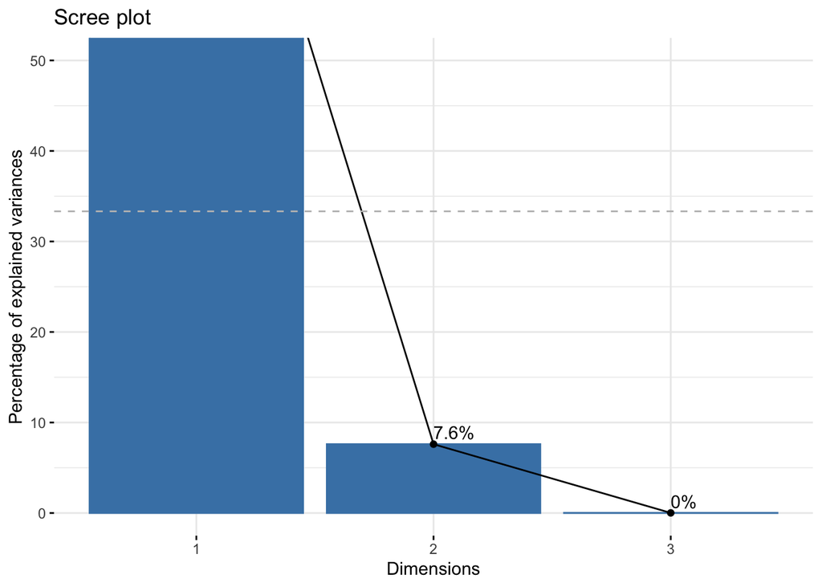

```r
fviz_screeplot(ca.model, addlabels = TRUE, ylim = c(0, 50)) +
  geom_hline(yintercept=33.33, linetype=2, color="grey")
```

### Biplot

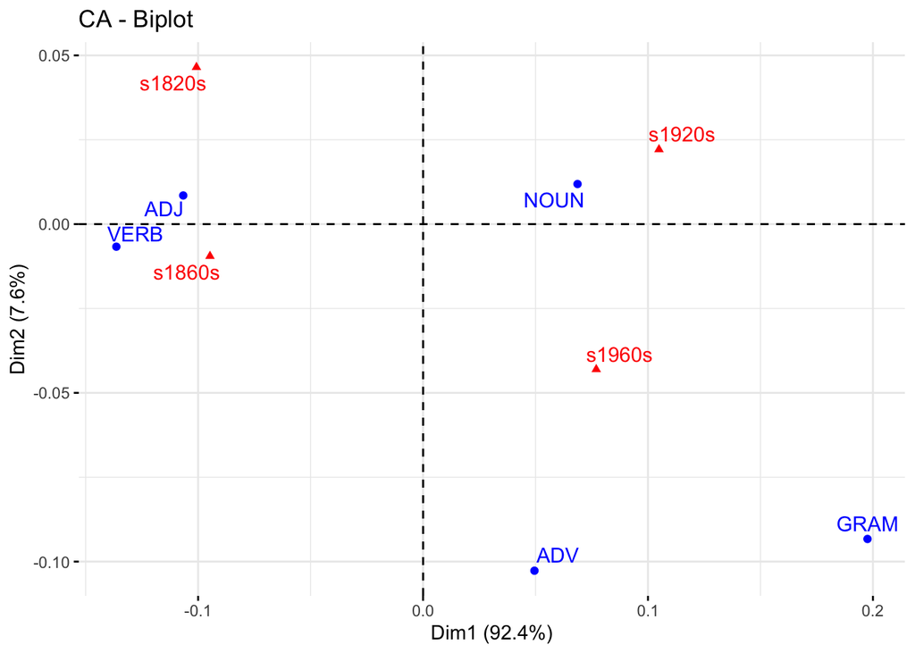

```r
fviz_ca_biplot(ca.model, repel = TRUE)
```

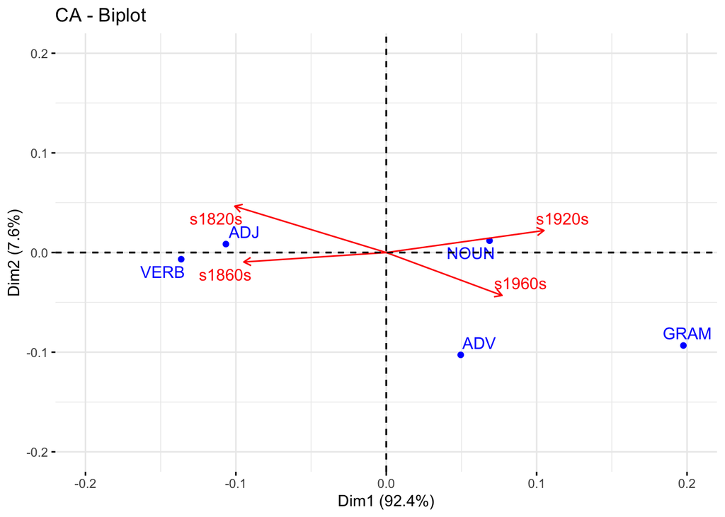

```r
# to make distances more reliable
fviz_ca_biplot(ca.model, repel = TRUE,
               geom.col = c("arrow", "text")) +
  xlim(-0.2, 0.2) + ylim (-0.2, 0.2)
```